# INF 772

## Mohammad Shafayet Jamil Hossain

```python
pwd
```

```
'C:\\Users\\mh734\\AMynewJNfolder INF772'
```

```python
import pandas as pd
df=pd.read_csv("company_sales_data.csv")
df.head(5)
```

|  | month_number | facecream | facewash | toothpaste | bathingsoap | shampoo | moisturizer | total_units | total_profit |
| --- | --- | --- | --- | --- | --- | --- | --- | --- | --- |
| 0 | 1 | 2500 | 1500 | 5200 | 9200 | 1200 | 1500 | 21100 | 211000 |
| 1 | 2 | 2630 | 1200 | 5100 | 6100 | 2100 | 1200 | 18330 | 183300 |
| 2 | 3 | 2140 | 1340 | 4550 | 9550 | 3550 | 1340 | 22470 | 224700 |
| 3 | 4 | 3400 | 1130 | 5870 | 8870 | 1870 | 1130 | 22270 | 222700 |
| 4 | 5 | 3600 | 1740 | 4560 | 7760 | 1560 | 1740 | 20960 | 209600 |

### Exercise 1:

Read Total profit of all months and show it using a line plot Total profit data provided for each month. Generated line plot must include the following properties: – X label name = Month Number Y label name = Total profit The line plot graph should look like this.

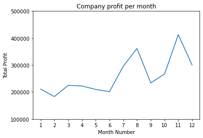

```python
import matplotlib.pyplot as plt
df=pd.read_csv("company_sales_data.csv")
p_list = df['total_profit'].tolist()
m_list = df['month_number'].tolist()
plt.plot(m_list, p_list)
plt.xlabel('Month Number')
plt.ylabel('Total Profit')
plt.xticks(m_list)
plt.title('Company profit per month')
plt.yticks([100000, 200000, 300000, 400000, 500000])
plt.show()
```

### Exercise 2:

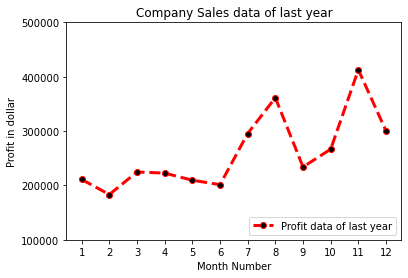

```python
plt.plot(m_list, p_list, label = 'Profit data of last year',
      color='r', marker='o', markerfacecolor='k',
      linestyle='--', linewidth=3)

plt.xlabel('Month Number')
plt.ylabel('Profit in dollar')
plt.legend(loc='lower right')
plt.title('Company Sales data of last year')
plt.xticks(m_list)
plt.yticks([100000, 200000, 300000, 400000, 500000])
plt.show()
```

### Exercise 3:

Read all product sales data and show it using a multiline plot  
Display the number of units sold per month for each product using multiline plots. (i.e., Separate Plotline for each product ). The graph should look like this.

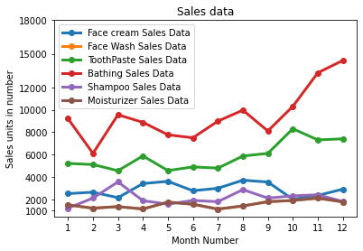

```python
f_Data     = df ['facecream'].tolist()
f_W_Data   = df ['facewash'].tolist()
t_P_Data   = df ['toothpaste'].tolist()
b_S_Data   = df ['bathingsoap'].tolist()
s_Data     = df ['shampoo'].tolist()
m_Data     = df ['moisturizer'].tolist()

plt.plot(m_list, f_Data,label = 'Face cream Sales Data', marker='o', linewidth=3)
plt.plot(m_list, f_W_Data,label = 'Face Wash Sales Data',  marker='o', linewidth=3)
plt.plot(m_list, t_P_Data,label = 'ToothPaste Sales Data', marker='o', linewidth=3)
plt.plot(m_list, b_S_Data,label = 'Bathing Sales Data', marker='o', linewidth=3)
plt.plot(m_list, s_Data,label = 'Shampoo Sales Data', marker='o', linewidth=3)
plt.plot(m_list, m_Data,label = 'Moisturizer Sales Data', marker='o', linewidth=3)

plt.xlabel('Month Number')
plt.ylabel('Sales units in number')
plt.legend(loc='upper left')
plt.xticks(m_list)
plt.yticks([1000, 2000, 4000, 6000, 8000, 10000, 12000, 15000, 18000])
plt.title('Sales data')
plt.show()
```

### Exercise 4:

Read toothpaste sales data of each month and show it using a scatter plot  
Also, add a grid in the plot. gridline style should “–“.  
The scatter plot should look like this.

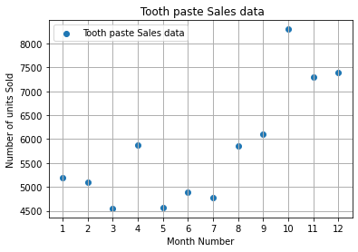

```python
plt.scatter(m_list, t_P_Data, label = 'Tooth paste Sales data')
plt.xlabel('Month Number')
plt.ylabel('Number of units Sold')
plt.legend(loc='upper left')
plt.title(' Tooth paste Sales data')
plt.xticks(m_list)
plt.grid(True, linewidth= 1, linestyle="-")
plt.show()
```

### Exercise 5:

Read face cream and facewash product sales data and show it using the bar chart  
The bar chart should display the number of units sold per month for each product. Add a separate bar for  
each product in the same chart.  
The bar chart should look like this.

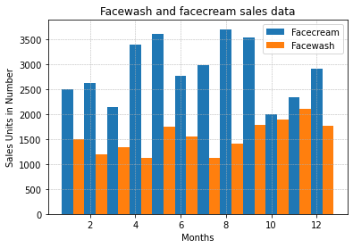

```python
plt.figure()
plt.bar(pd.array(m_list), f_Data  , width=0.5,  label="Facecream")
plt.bar(pd.array(m_list) + 0.5, f_W_Data ,  width = 0.5, label="Facewash")
plt.legend(loc = 1)
plt.grid(linestyle ='--' ,linewidth = .5)
plt.xlabel("Months")
plt.ylabel("Sales Units in Number")
plt.title("Facewash and facecream sales data")
plt.show()
```

### Exercise 6:

Read sales data of bathing soap of all months and show it using a bar chart. Save this plot to your hard disk

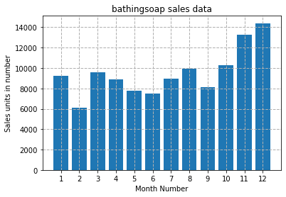

```python
plt.bar(m_list, b_S_Data )
plt.xlabel('Month Number')
plt.ylabel('Sales units in number')
plt.title(' Sales data')
plt.xticks(m_list)
plt.grid(True, linewidth= 1, linestyle="--")
plt.title('bathingsoap sales data')
plt.savefig('C:')
plt.show()
```

### Exercise 7:

Read the total profit of each month and show it using the histogram to see most common profit ranges

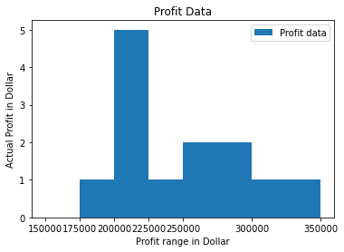

```python
profit_range = [150000, 175000, 200000, 225000, 250000, 300000, 350000]
plt.hist(p_list, profit_range, label = 'Profit data')
plt.xlabel("Profit range in Dollar")
plt.ylabel("Actual Profit in Dollar")
plt.title("Profit Data")
plt.legend(loc=1)
plt.xticks(profit_range)
plt.show()
```

### Exercise 8:

Calculate total sale data for last year for each product and show it using a Pie chart

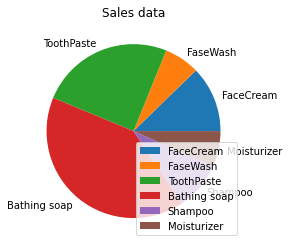

```python
salesData   = [df ['facecream'].sum(), df ['facewash'].sum(), df ['toothpaste'].sum(),
               df ['bathingsoap'].sum(), df ['shampoo'].sum(), df ['moisturizer'].sum()]

labels = ['FaceCream', 'FaseWash', 'ToothPaste', 'Bathing soap', 'Shampoo', 'Moisturizer']
plt.pie(salesData, labels=labels)
plt.legend(loc='lower right')
plt.title('Sales data')
plt.show()
```

Exercise 9: Read Bathing soap facewash of all months and display it using the Subplot

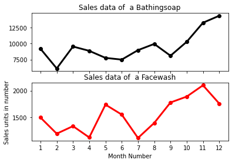

```python
f, axarr = plt.subplots(2, sharex=True)
axarr[0].plot(m_list, b_S_Data, label = 'Bathingsoap Sales Data', color='k', marker='o', linewidth=3)
axarr[0].set_title('Sales data of  a Bathingsoap')
axarr[1].plot(m_list, f_W_Data , label = 'Face Wash Sales Data', color='r', marker='o', linewidth=3)
axarr[1].set_title('Sales data of  a Facewash')

plt.xticks(m_list)
plt.xlabel('Month Number')
plt.ylabel('Sales units in number')
plt.show()
```

Exercise 10: Read all product sales data and show it using the stack plot

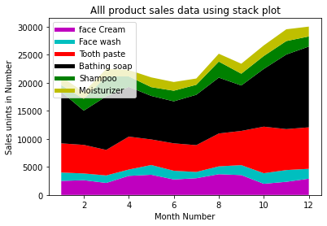

```python
plt.plot([],[],color='m', label='face Cream', linewidth=5)
plt.plot([],[],color='c', label='Face wash', linewidth=5)
plt.plot([],[],color='r', label='Tooth paste', linewidth=5)
plt.plot([],[],color='k', label='Bathing soap', linewidth=5)
plt.plot([],[],color='g', label='Shampoo', linewidth=5)
plt.plot([],[],color='y', label='Moisturizer', linewidth=5)


f_Data     = df ['facecream'].tolist()
f_W_Data   = df ['facewash'].tolist()
t_P_Data   = df ['toothpaste'].tolist()
b_S_Data   = df ['bathingsoap'].tolist()
s_Data     = df ['shampoo'].tolist()
m_Data     = df ['moisturizer'].tolist()


plt.stackplot(m_list, f_Data, f_W_Data , t_P_Data ,
              b_S_Data, s_Data ,m_Data,
              colors=['m','c','r','k','g','y'])

plt.xlabel('Month Number')
plt.ylabel('Sales unints in Number')
plt.title('Alll product sales data using stack plot')
plt.legend(loc='upper left')
plt.show()
```